# PAIN RELIEF

[figure not shown]

[figure not shown]

### **Sports injuries, Deep tissue massage, Muscle knots, Repetitive stress injuries**

If you’ve ever had a stubborn knot in your neck or back that just won’t go away, you may be dealing with a trigger point.

A trigger point is a pressure-sensitive area in the muscle that is frequently linked with pain and stiffness. Trigger points can be extremely painful, limiting your range of motion and making it difficult to engage in daily activities.

They often feel like small, hard nodules or knots underneath the skin or atop muscles, and they can cause pain either at the site or in a nearby area of the body. For example, a trigger point in your shoulder might not only cause direct soreness in your shoulder muscle, but could also result in a headache or arm pain. These points can form due to overuse, injury, stress, poor posture, or muscle imbalances.

Trigger point therapy is a massage therapy methodology that involves a targeted approach to relieve muscle tension and movement. It also alleviates exercise strain by reducing muscle soreness, improving bloodflow and accelerating recovery. It increases flexibility and range of motion, flushes out metabolic waste, and reduces inflammation, reducing in turn the risk of future injuries.

### Half session: MYR 125

Half-hour. For single issues or preventative maintenance.

### Full works: MYR 250

Full hour. Give your body a full tune up. Or for problems that are widespread or particularly complex.

##### Discounts available for the elderly, people with disabilities, manual labourers and migrant workers.

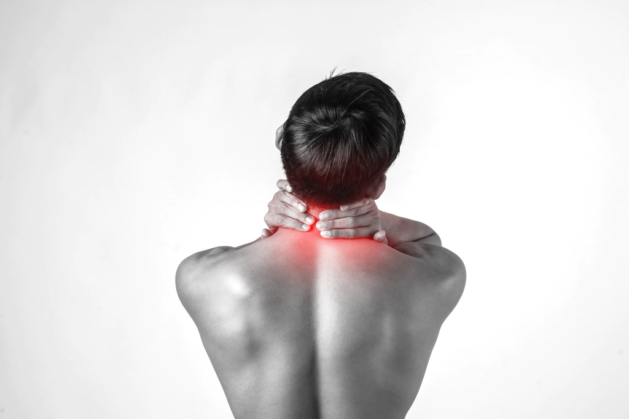

[Intake form](https://docs.google.com/forms/d/e/1FAIpQLSe81vMPhvQ1SQnrnYRcRiuGBNTZ74gj7-oXLQnpq-AXKrNOdA/viewform?usp=sharing&ouid=105993754945012017009)